# NBA Player Prediction Points. A Machine Learning project using Python

## Importing libraries

```python
import pandas as pd
import seaborn as sns
import numpy as np
import matplotlib.pyplot as plt
from bs4 import BeautifulSoup
```

## Request players Stats table

The data was read through the url using the 'requests' import.

```python
import requests
req = requests.get("https://www.basketball-reference.com/leagues/NBA_2021_totals.html").content
```

[output not shown]

# Data without repeating players

```python
soup2 = BeautifulSoup(req, 'html.parser')
```

This module defines an HTMLParser class that serves as a basis for parsing text files formatted in HTML (HyperText Mark-up Language) and XHTML.

```python
### Data without repetition

dados_sr = soup2.findAll('tr', class_= "full_table")
len(dados_sr)
```

```
540
```

Separating the data found on the site, ' tr ' refers to the beginning of the table and ' full_table ' to non-repeating data.

```python
for tabela in dados_sr:
  for character in tabela:
    if(character.string == None):
      character.string = "0"
```

A 'for' was created to fill the NA values found in the table with 0.

Verifying if NA's now are zero with one sample.

```python
dados_sr[12].get_text(',')
```

```
'13,Kostas Antetokounmpo,PF,23,LAL,15,0,56,3,10,.300,0,0,0,3,10,.300,.300,6,13,.462,4,15,19,1,2,4,11,8,12'
```

```python
dados_sr = [character.get_text(',').split(',') for character in dados_sr ]
```

Using the '.get.text' and '.split' commands, selecting the website texts and separating them respectively. Now it is possible to create a DataFrame.

Extrating titles

```python
titles = soup2.find('tr')
header = [id for id in titles.stripped_strings if id != '\n']
print(header)
```

```
['Rk', 'Player', 'Pos', 'Age', 'Tm', 'G', 'GS', 'MP', 'FG', 'FGA', 'FG%', '3P', '3PA', '3P%', '2P', '2PA', '2P%', 'eFG%', 'FT', 'FTA', 'FT%', 'ORB', 'DRB', 'TRB', 'AST', 'STL', 'BLK', 'TOV', 'PF', 'PTS']
```

Another ' for ' was created to select and separate each value from the table

```python
dados_sr = pd.DataFrame(dados_sr,  columns= header)
dados_sr.drop("Rk", axis=1, inplace = True)
dados_sr[0:5]
```

|  | Player | Pos | Age | Tm | G | GS | MP | FG | FGA | FG% | ... | FT% | ORB | DRB | TRB | AST | STL | BLK | TOV | PF | PTS |
| --- | --- | --- | --- | --- | --- | --- | --- | --- | --- | --- | --- | --- | --- | --- | --- | --- | --- | --- | --- | --- | --- |
| 0 | Precious Achiuwa | PF | 21 | MIA | 61 | 4 | 737 | 124 | 228 | .544 | ... | .509 | 73 | 135 | 208 | 29 | 20 | 28 | 43 | 91 | 304 |
| 1 | Jaylen Adams | PG | 24 | MIL | 7 | 0 | 18 | 1 | 8 | .125 | ... | 0 | 0 | 3 | 3 | 2 | 0 | 0 | 0 | 1 | 2 |
| 2 | Steven Adams | C | 27 | NOP | 58 | 58 | 1605 | 189 | 308 | .614 | ... | .444 | 213 | 301 | 514 | 111 | 54 | 38 | 78 | 113 | 438 |
| 3 | Bam Adebayo | C | 23 | MIA | 64 | 64 | 2143 | 456 | 800 | .570 | ... | .799 | 142 | 431 | 573 | 346 | 75 | 66 | 169 | 145 | 1197 |
| 4 | LaMarcus Aldridge | C | 35 | TOT | 26 | 23 | 674 | 140 | 296 | .473 | ... | .872 | 19 | 99 | 118 | 49 | 11 | 29 | 27 | 47 | 352 |

5 rows × 29 columns

# Data repeating players

```python
soup = BeautifulSoup(req, 'html.parser')
#soup.prettify()
```

```python
# Data repeating players

dados_cr = soup.findAll('tr', attrs={"class": ["italic_text partial_table", "full_table"]})
len(dados_cr)
```

```
705
```

```python
for tabela in dados_cr:
  for character in tabela:
    if(character.string == None):
      character.string = "0"
```

```python
dados_finais_cr = [ character.get_text(',').split(',') for character in dados_cr]
```

```python
titles = soup.find('tr')
header = [id for id in titles.stripped_strings]
print(header)
```

```
['Rk', 'Player', 'Pos', 'Age', 'Tm', 'G', 'GS', 'MP', 'FG', 'FGA', 'FG%', '3P', '3PA', '3P%', '2P', '2PA', '2P%', 'eFG%', 'FT', 'FTA', 'FT%', 'ORB', 'DRB', 'TRB', 'AST', 'STL', 'BLK', 'TOV', 'PF', 'PTS']
```

```python
dados_cr = pd.DataFrame(dados_finais_cr, columns= header)
#dados_cr.drop("Rk", axis=1, inplace = True)
dados_cr[0:5]
```

|  | Rk | Player | Pos | Age | Tm | G | GS | MP | FG | FGA | ... | FT% | ORB | DRB | TRB | AST | STL | BLK | TOV | PF | PTS |
| --- | --- | --- | --- | --- | --- | --- | --- | --- | --- | --- | --- | --- | --- | --- | --- | --- | --- | --- | --- | --- | --- |
| 0 | 1 | Precious Achiuwa | PF | 21 | MIA | 61 | 4 | 737 | 124 | 228 | ... | .509 | 73 | 135 | 208 | 29 | 20 | 28 | 43 | 91 | 304 |
| 1 | 2 | Jaylen Adams | PG | 24 | MIL | 7 | 0 | 18 | 1 | 8 | ... | 0 | 0 | 3 | 3 | 2 | 0 | 0 | 0 | 1 | 2 |
| 2 | 3 | Steven Adams | C | 27 | NOP | 58 | 58 | 1605 | 189 | 308 | ... | .444 | 213 | 301 | 514 | 111 | 54 | 38 | 78 | 113 | 438 |
| 3 | 4 | Bam Adebayo | C | 23 | MIA | 64 | 64 | 2143 | 456 | 800 | ... | .799 | 142 | 431 | 573 | 346 | 75 | 66 | 169 | 145 | 1197 |
| 4 | 5 | LaMarcus Aldridge | C | 35 | TOT | 26 | 23 | 674 | 140 | 296 | ... | .872 | 19 | 99 | 118 | 49 | 11 | 29 | 27 | 47 | 352 |

5 rows × 30 columns

# Exploratory Analysis - without repeating players

```python
names = dados_sr.columns
names
```

```
Index(['Player', 'Pos', 'Age', 'Tm', 'G', 'GS', 'MP', 'FG', 'FGA', 'FG%', '3P',
       '3PA', '3P%', '2P', '2PA', '2P%', 'eFG%', 'FT', 'FTA', 'FT%', 'ORB',
       'DRB', 'TRB', 'AST', 'STL', 'BLK', 'TOV', 'PF', 'PTS'],
      dtype='object')
```

```python
dados_sr.info()
```

```
<class 'pandas.core.frame.DataFrame'>
RangeIndex: 540 entries, 0 to 539
Data columns (total 29 columns):
 #   Column  Non-Null Count  Dtype
---  ------  --------------  -----
 0   Player  540 non-null    object
 1   Pos     540 non-null    object
 2   Age     540 non-null    object
 3   Tm      540 non-null    object
 4   G       540 non-null    object
 5   GS      540 non-null    object
 6   MP      540 non-null    object
 7   FG      540 non-null    object
 8   FGA     540 non-null    object
 9   FG%     540 non-null    object
```

[output cut: 21 more lines]

```python
#dados_srp['Age'] = dados_srp['Age'].apply(np.int64)
#dados_srp['PTS'] = dados_srp['PTS'].apply(np.int64)
#dados_srp['PTS'] = dados_srp['PTS'].apply(np.int64)
#dados_srp['MP'] = dados_srp['MP'].apply(np.int64)...
```

```python
#import re
#for ind in dados_srp:
#  if re.match('^\d+$', dados_srp[ind][0]):
#    dados_srp[ind] = pd.to_numeric(dados_srp[ind])
#  elif re.match('^.\d+$', dados_srp[ind][0]):
#    print(2)
#    dados_srp[ind] = pd.to_numeric(dados_srp[ind])
#dados_srp.info()
```

## Transforming Dtypes for analysis

```python
import re
for ind in dados_sr:
  if re.match('^\d+$', dados_sr[ind][0]):
    dados_sr[ind] = pd.to_numeric(dados_sr[ind])
  elif re.match('^.\d+$', dados_sr[ind][0]):
    dados_sr[ind] = pd.to_numeric(dados_sr[ind])
dados_sr.info()
```

```
<class 'pandas.core.frame.DataFrame'>
RangeIndex: 540 entries, 0 to 539
Data columns (total 29 columns):
 #   Column  Non-Null Count  Dtype
---  ------  --------------  -----
 0   Player  540 non-null    object
 1   Pos     540 non-null    object
 2   Age     540 non-null    int64
 3   Tm      540 non-null    object
 4   G       540 non-null    int64
 5   GS      540 non-null    int64
 6   MP      540 non-null    int64
 7   FG      540 non-null    int64
 8   FGA     540 non-null    int64
 9   FG%     540 non-null    float64
```

[output cut: 21 more lines]

## Players Age

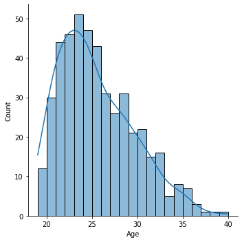

```python
sns.displot(dados_sr['Age'], kde=True,alpha = 0.5,bins=21)
```

It is possible to identify by the histogram that most players are between 21 and 25 years old.

## Position x Points

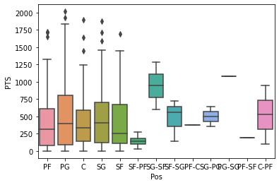

```python
sns.boxplot(data = dados_sr, x = 'Pos', y = 'PTS');
```

## Minutes Played x Points

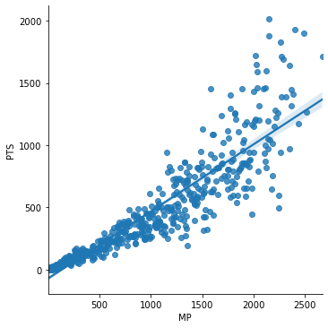

```python
sns.lmplot(x = 'MP' ,y='PTS', data = dados_sr);
```

## Field Goals x Points

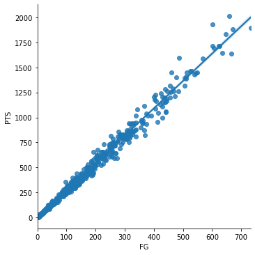

```python
sns.lmplot(data = dados_sr, x = 'FG', y = 'PTS');
```

## Field Goals Attempts x Points

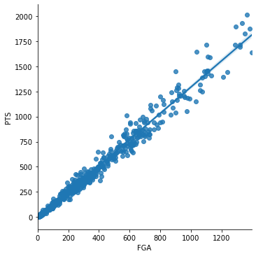

```python
sns.lmplot(data = dados_sr, x = 'FGA', y = 'PTS');
```

## Turnovers x Points

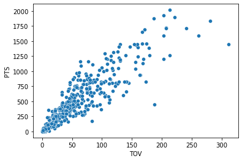

```python
sns.scatterplot(data = dados_sr, x = 'TOV', y = 'PTS');
```

## Minutes played per games X Points

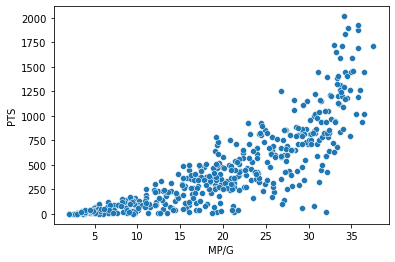

```python
dados_sr['MP/G'] = dados_sr['MP'] / dados_sr['G']
sns.scatterplot(data = dados_sr, x = 'MP/G', y = 'PTS');
```

## Points per Team

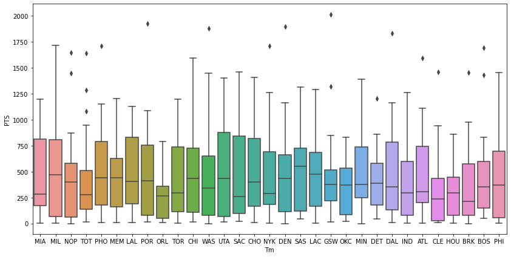

```python
plt.figure(figsize = (14,7))
sns.boxplot(data = dados_sr, x = 'Tm', y = 'PTS');
```

## Points per Age

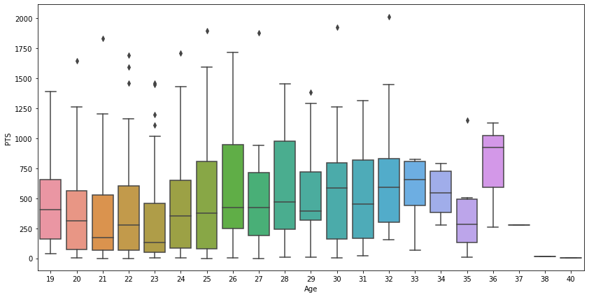

```python
plt.figure(figsize = (14,7))
sns.boxplot(data = dados_sr, x = 'Age', y ='PTS');
```

## Variables correlation with Points

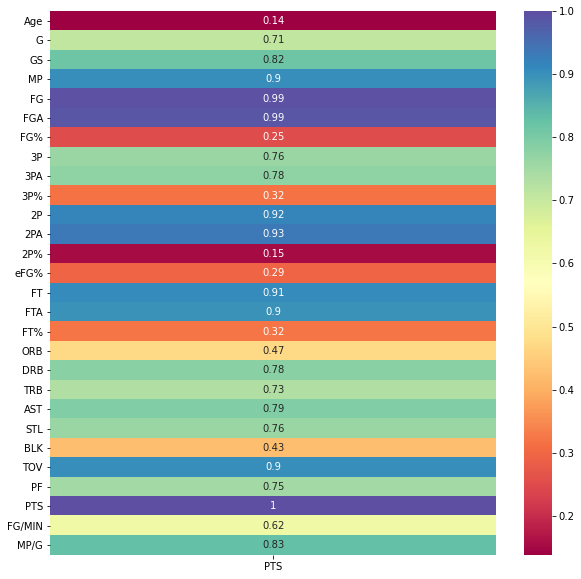

```python
plt.figure(figsize = (10,10))
sns.heatmap(dados_sr.corr()['PTS'].to_frame(), annot = True,cmap="Spectral");
```

## Variables Heatmap

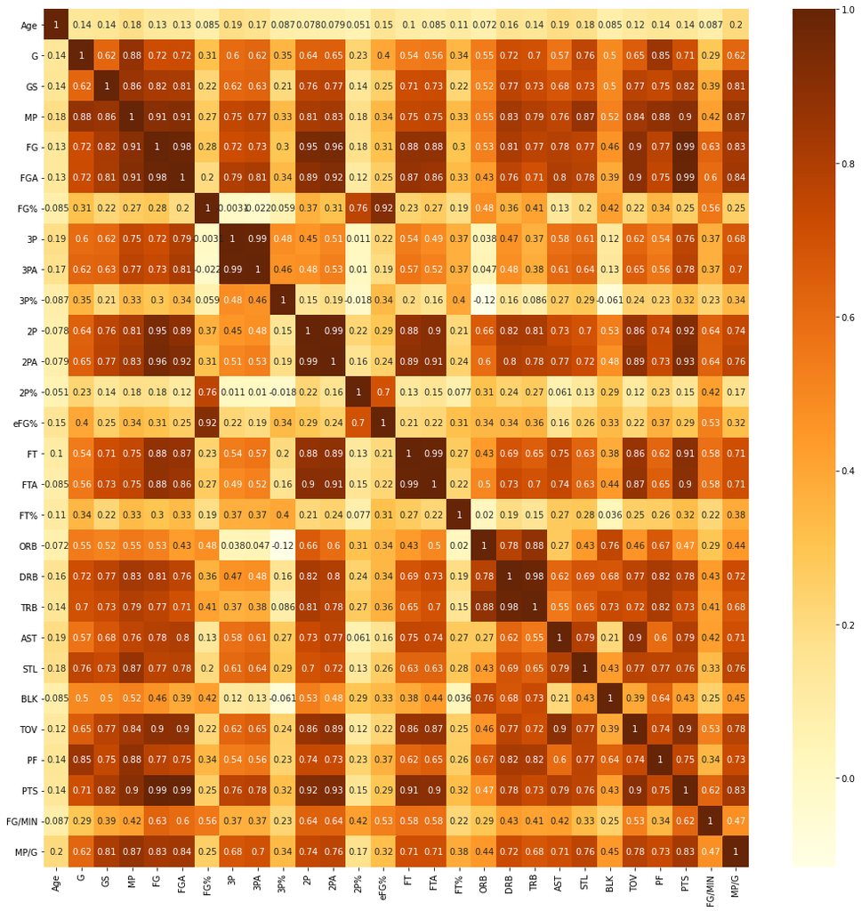

```python
plt.figure(figsize = (18,18))
sns.heatmap(dados_sr.corr(), annot = True,cmap ="YlOrBr");
```

```python
times = dados_sr['Tm'].unique()
times
```

```
array(['MIA', 'MIL', 'NOP', 'TOT', 'PHO', 'MEM', 'LAL', 'POR', 'ORL',
       'TOR', 'CHI', 'WAS', 'UTA', 'SAC', 'CHO', 'NYK', 'DEN', 'SAS',
       'LAC', 'GSW', 'OKC', 'MIN', 'DET', 'DAL', 'IND', 'ATL', 'CLE',
       'HOU', 'BRK', 'BOS', 'PHI'], dtype=object)
```

```python
sep_times = dados_sr.groupby('Tm').groups
for time in sep_times:
  sep_times[time] = sum(sep_times[time])

valores = sep_times.values()
indice = sep_times.keys()
pt_por_time = pd.DataFrame(data = valores, index = indice)
pt_por_time.reset_index(inplace=True)
pt_por_time.columns = ['Team','Points']
```

[figure not shown]

```python
import matplotlib.pyplot as plt
plt.figure(figsize = (20,5))
sns.barplot(x = pt_por_time['Team'],y=pt_por_time['Points']);
```

```python
cont = 0
for i in dados_sr['Tm']:
  if i == 'TOT':
    cont+=1
cont
```

```
79
```

## Players with highest score points

```python
maiores_pontuadores = dados_sr['PTS'].nlargest(10)
maiores_pontuadores = maiores_pontuadores.reset_index()
lista = maiores_pontuadores['index'].to_list()
maiores_frame = dados_sr.loc[lista]
maiores_frame['PTP'] = str('nan')
maiores_frame.reset_index(inplace= True)
maiores_frame
for player in range( 0,len(maiores_frame)):
  maiores_frame.at[player,'PTP'] = maiores_frame.iloc[player]['Player'] + '\n' + maiores_frame.iloc[player]['Pos'] + '\n' + maiores_frame.iloc[player]['Tm']
```

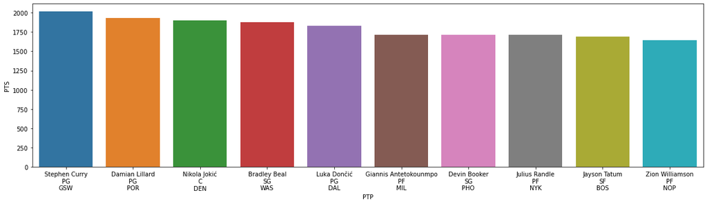

```python
plt.figure(figsize = (20,5))
sns.barplot(data = maiores_frame, x = 'PTP', y = 'PTS');
```

```python
dois_times = dados_sr[dados_sr['Tm'] == 'TOT']
dados_sr.drop(dois_times.reset_index()['index'], inplace = True)
plt.figure(figsize = (20,5))
# sns.barplot(x = pt_por_time['Time'],y=pt_por_time['Pontos']);
```

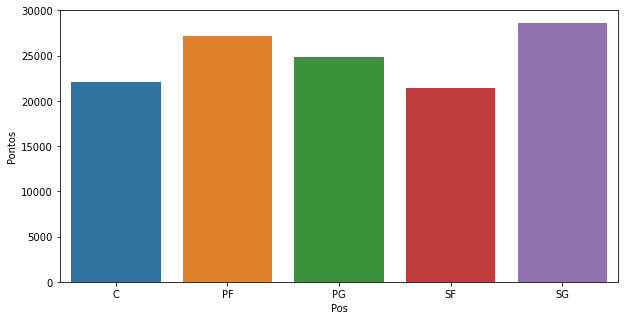

```python
sep_pos = dados_sr.groupby('Pos').groups
for pos in sep_pos:
  sep_pos[pos] = sum(sep_pos[pos])

valores = sep_pos.values()
indice = sep_pos.keys()
pt_por_pos = pd.DataFrame(data = valores, index = indice)
pt_por_pos.reset_index(inplace=True)
pt_por_pos.columns = ['Pos','Pontos']

plt.figure(figsize = (10,5))
sns.barplot(x = pt_por_pos['Pos'],y=pt_por_pos['Pontos']);
```

# Data Manipulation to create a Supervised Machine Learning Model

Was use the non-repetiton Players data.

```python
#dados_sr.drop('FGA',inplace = True, axis='columns')
dados_sr.drop('3PA',inplace = True, axis='columns')
dados_sr.drop('3P',inplace = True, axis='columns')
dados_sr.drop('2P',inplace = True, axis='columns')
dados_sr.drop('2PA',inplace = True, axis='columns')
dados_sr.drop('FT',inplace = True, axis='columns')
dados_sr.drop('FTA',inplace = True, axis='columns')
#dados_sr.drop('Rk',inplace = True, axis='columns')
dados_sr.drop('FG',inplace = True, axis='columns')
```

```python
dados_sr.drop('FG/MIN',inplace = True, axis='columns')
dados_sr.drop('MP/G',inplace = True, axis='columns')
```

## A Different Numerical Heatmap

```python
dados_sr.corr().style.background_gradient(cmap='BrBG').set_precision(2)
# 'RdBu_r' & 'coolwarm' are other good diverging colormaps
```

|  | Age | G | GS | MP | FGA | FG% | 3P% | 2P% | eFG% | FT% | ORB | DRB | TRB | AST | STL | BLK | TOV | PF | PTS |
| --- | --- | --- | --- | --- | --- | --- | --- | --- | --- | --- | --- | --- | --- | --- | --- | --- | --- | --- | --- |
| Age | 1.00 | 0.14 | 0.17 | 0.20 | 0.14 | 0.11 | 0.08 | 0.07 | 0.18 | 0.08 | 0.10 | 0.18 | 0.17 | 0.19 | 0.18 | 0.10 | 0.12 | 0.16 | 0.15 |
| G | 0.14 | 1.00 | 0.63 | 0.88 | 0.73 | 0.32 | 0.39 | 0.23 | 0.41 | 0.35 | 0.55 | 0.73 | 0.71 | 0.57 | 0.76 | 0.50 | 0.65 | 0.86 | 0.71 |
| GS | 0.17 | 0.63 | 1.00 | 0.86 | 0.82 | 0.22 | 0.23 | 0.13 | 0.25 | 0.24 | 0.51 | 0.76 | 0.73 | 0.69 | 0.74 | 0.49 | 0.78 | 0.75 | 0.82 |
| MP | 0.20 | 0.88 | 0.86 | 1.00 | 0.91 | 0.28 | 0.37 | 0.18 | 0.35 | 0.34 | 0.55 | 0.84 | 0.80 | 0.76 | 0.87 | 0.52 | 0.84 | 0.89 | 0.90 |
| FGA | 0.14 | 0.73 | 0.82 | 0.91 | 1.00 | 0.21 | 0.37 | 0.12 | 0.26 | 0.34 | 0.42 | 0.76 | 0.70 | 0.80 | 0.78 | 0.38 | 0.90 | 0.76 | 0.99 |
| FG% | 0.11 | 0.32 | 0.22 | 0.28 | 0.21 | 1.00 | 0.06 | 0.76 | 0.92 | 0.21 | 0.48 | 0.37 | 0.42 | 0.14 | 0.22 | 0.40 | 0.22 | 0.35 | 0.25 |
| 3P% | 0.08 | 0.39 | 0.23 | 0.37 | 0.37 | 0.06 | 1.00 | -0.02 | 0.35 | 0.41 | -0.10 | 0.18 | 0.11 | 0.29 | 0.31 | -0.04 | 0.27 | 0.27 | 0.35 |
| 2P% | 0.07 | 0.23 | 0.13 | 0.18 | 0.12 | 0.76 | -0.02 | 1.00 | 0.69 | 0.10 | 0.30 | 0.24 | 0.27 | 0.07 | 0.13 | 0.27 | 0.12 | 0.23 | 0.15 |
| eFG% | 0.18 | 0.41 | 0.25 | 0.35 | 0.26 | 0.92 | 0.35 | 0.69 | 1.00 | 0.33 | 0.34 | 0.35 | 0.36 | 0.16 | 0.27 | 0.32 | 0.22 | 0.37 | 0.29 |
| FT% | 0.08 | 0.35 | 0.24 | 0.34 | 0.34 | 0.21 | 0.41 | 0.10 | 0.33 | 1.00 | 0.03 | 0.21 | 0.17 | 0.27 | 0.29 | 0.05 | 0.26 | 0.27 | 0.33 |
| ORB | 0.10 | 0.55 | 0.51 | 0.55 | 0.42 | 0.48 | -0.10 | 0.30 | 0.34 | 0.03 | 1.00 | 0.78 | 0.88 | 0.28 | 0.43 | 0.75 | 0.45 | 0.68 | 0.47 |
| DRB | 0.18 | 0.73 | 0.76 | 0.84 | 0.76 | 0.37 | 0.18 | 0.24 | 0.35 | 0.21 | 0.78 | 1.00 | 0.98 | 0.63 | 0.69 | 0.68 | 0.77 | 0.83 | 0.78 |
| TRB | 0.17 | 0.71 | 0.73 | 0.80 | 0.70 | 0.42 | 0.11 | 0.27 | 0.36 | 0.17 | 0.88 | 0.98 | 1.00 | 0.56 | 0.65 | 0.73 | 0.72 | 0.82 | 0.73 |
| AST | 0.19 | 0.57 | 0.69 | 0.76 | 0.80 | 0.14 | 0.29 | 0.07 | 0.16 | 0.27 | 0.28 | 0.63 | 0.56 | 1.00 | 0.79 | 0.21 | 0.90 | 0.61 | 0.79 |
| STL | 0.18 | 0.76 | 0.74 | 0.87 | 0.78 | 0.22 | 0.31 | 0.13 | 0.27 | 0.29 | 0.43 | 0.69 | 0.65 | 0.79 | 1.00 | 0.43 | 0.77 | 0.77 | 0.76 |
| BLK | 0.10 | 0.50 | 0.49 | 0.52 | 0.38 | 0.40 | -0.04 | 0.27 | 0.32 | 0.05 | 0.75 | 0.68 | 0.73 | 0.21 | 0.43 | 1.00 | 0.39 | 0.64 | 0.42 |
| TOV | 0.12 | 0.65 | 0.78 | 0.84 | 0.90 | 0.22 | 0.27 | 0.12 | 0.22 | 0.26 | 0.45 | 0.77 | 0.72 | 0.90 | 0.77 | 0.39 | 1.00 | 0.74 | 0.90 |
| PF | 0.16 | 0.86 | 0.75 | 0.89 | 0.76 | 0.35 | 0.27 | 0.23 | 0.37 | 0.27 | 0.68 | 0.83 | 0.82 | 0.61 | 0.77 | 0.64 | 0.74 | 1.00 | 0.76 |
| PTS | 0.15 | 0.71 | 0.82 | 0.90 | 0.99 | 0.25 | 0.35 | 0.15 | 0.29 | 0.33 | 0.47 | 0.78 | 0.73 | 0.79 | 0.76 | 0.42 | 0.90 | 0.76 | 1.00 |

```python
dados_sr.info()
```

```
<class 'pandas.core.frame.DataFrame'>
Int64Index: 461 entries, 0 to 539
Data columns (total 22 columns):
 #   Column  Non-Null Count  Dtype
---  ------  --------------  -----
 0   Player  461 non-null    object
 1   Pos     461 non-null    object
 2   Age     461 non-null    int64
 3   Tm      461 non-null    object
 4   G       461 non-null    int64
 5   GS      461 non-null    int64
 6   MP      461 non-null    int64
 7   FGA     461 non-null    int64
 8   FG%     461 non-null    float64
 9   3P%     461 non-null    float64
 10  2P%     461 non-null    float64
 11  eFG%    461 non-null    float64
 12  FT%     461 non-null    float64
 13  ORB     461 non-null    int64
 14  DRB     461 non-null    int64
 15  TRB     461 non-null    int64
 16  AST     461 non-null    int64
 17  STL     461 non-null    int64
 18  BLK     461 non-null    int64
 19  TOV     461 non-null    int64
 20  PF      461 non-null    int64
 21  PTS     461 non-null    int64
dtypes: float64(5), int64(14), object(3)
memory usage: 82.8+ KB
```

```python
dados_sr
```

|  | Player | Pos | Age | Tm | G | GS | MP | FGA | FG% | 3P% | ... | FT% | ORB | DRB | TRB | AST | STL | BLK | TOV | PF | PTS |
| --- | --- | --- | --- | --- | --- | --- | --- | --- | --- | --- | --- | --- | --- | --- | --- | --- | --- | --- | --- | --- | --- |
| 0 | Precious Achiuwa | PF | 21 | MIA | 61 | 4 | 737 | 228 | 0.544 | 0.000 | ... | 0.509 | 73 | 135 | 208 | 29 | 20 | 28 | 43 | 91 | 304 |
| 1 | Jaylen Adams | PG | 24 | MIL | 7 | 0 | 18 | 8 | 0.125 | 0.000 | ... | 0.000 | 0 | 3 | 3 | 2 | 0 | 0 | 0 | 1 | 2 |
| 2 | Steven Adams | C | 27 | NOP | 58 | 58 | 1605 | 308 | 0.614 | 0.000 | ... | 0.444 | 213 | 301 | 514 | 111 | 54 | 38 | 78 | 113 | 438 |
| 3 | Bam Adebayo | C | 23 | MIA | 64 | 64 | 2143 | 800 | 0.570 | 0.250 | ... | 0.799 | 142 | 431 | 573 | 346 | 75 | 66 | 169 | 145 | 1197 |
| 5 | Ty-Shon Alexander | SG | 22 | PHO | 15 | 0 | 47 | 12 | 0.250 | 0.222 | ... | 0.500 | 2 | 8 | 10 | 6 | 0 | 1 | 3 | 2 | 9 |
| ... | ... | ... | ... | ... | ... | ... | ... | ... | ... | ... | ... | ... | ... | ... | ... | ... | ... | ... | ... | ... | ... |
| 534 | Robert Woodard II | SF | 21 | SAC | 13 | 0 | 45 | 20 | 0.400 | 0.167 | ... | 0.375 | 4 | 12 | 16 | 2 | 0 | 3 | 1 | 4 | 20 |
| 536 | Thaddeus Young | PF | 32 | CHI | 68 | 23 | 1652 | 662 | 0.559 | 0.267 | ... | 0.628 | 168 | 255 | 423 | 291 | 74 | 40 | 137 | 152 | 823 |
| 537 | Trae Young | PG | 22 | ATL | 63 | 63 | 2125 | 1112 | 0.438 | 0.343 | ... | 0.886 | 38 | 207 | 245 | 594 | 53 | 12 | 261 | 111 | 1594 |
| 538 | Cody Zeller | C | 28 | CHO | 48 | 21 | 1005 | 324 | 0.559 | 0.143 | ... | 0.714 | 119 | 209 | 328 | 86 | 27 | 17 | 51 | 121 | 451 |
| 539 | Ivica Zubac | C | 23 | LAC | 72 | 33 | 1609 | 394 | 0.652 | 0.250 | ... | 0.789 | 189 | 330 | 519 | 90 | 24 | 62 | 81 | 187 | 650 |

461 rows × 22 columns

```python
dados_sr.drop('Player',inplace = True, axis='columns')
dados_sr.drop('Pos',inplace = True, axis='columns')
dados_sr.drop('Tm',inplace = True, axis='columns')
```

```python
dados_sr.info()
```

```
<class 'pandas.core.frame.DataFrame'>
Int64Index: 461 entries, 0 to 539
Data columns (total 19 columns):
 #   Column  Non-Null Count  Dtype
---  ------  --------------  -----
 0   Age     461 non-null    int64
 1   G       461 non-null    int64
 2   GS      461 non-null    int64
 3   MP      461 non-null    int64
 4   FGA     461 non-null    int64
 5   FG%     461 non-null    float64
 6   3P%     461 non-null    float64
 7   2P%     461 non-null    float64
 8   eFG%    461 non-null    float64
 9   FT%     461 non-null    float64
 10  ORB     461 non-null    int64
 11  DRB     461 non-null    int64
 12  TRB     461 non-null    int64
 13  AST     461 non-null    int64
 14  STL     461 non-null    int64
 15  BLK     461 non-null    int64
 16  TOV     461 non-null    int64
 17  PF      461 non-null    int64
 18  PTS     461 non-null    int64
dtypes: float64(5), int64(14)
memory usage: 72.0 KB
```

```python
dados_sr
```

|  | Age | G | GS | MP | FGA | FG% | 3P% | 2P% | eFG% | FT% | ORB | DRB | TRB | AST | STL | BLK | TOV | PF | PTS |
| --- | --- | --- | --- | --- | --- | --- | --- | --- | --- | --- | --- | --- | --- | --- | --- | --- | --- | --- | --- |
| 0 | 21 | 61 | 4 | 737 | 228 | 0.544 | 0.000 | 0.546 | 0.544 | 0.509 | 73 | 135 | 208 | 29 | 20 | 28 | 43 | 91 | 304 |
| 1 | 24 | 7 | 0 | 18 | 8 | 0.125 | 0.000 | 0.167 | 0.125 | 0.000 | 0 | 3 | 3 | 2 | 0 | 0 | 0 | 1 | 2 |
| 2 | 27 | 58 | 58 | 1605 | 308 | 0.614 | 0.000 | 0.620 | 0.614 | 0.444 | 213 | 301 | 514 | 111 | 54 | 38 | 78 | 113 | 438 |
| 3 | 23 | 64 | 64 | 2143 | 800 | 0.570 | 0.250 | 0.573 | 0.571 | 0.799 | 142 | 431 | 573 | 346 | 75 | 66 | 169 | 145 | 1197 |
| 5 | 22 | 15 | 0 | 47 | 12 | 0.250 | 0.222 | 0.333 | 0.333 | 0.500 | 2 | 8 | 10 | 6 | 0 | 1 | 3 | 2 | 9 |
| ... | ... | ... | ... | ... | ... | ... | ... | ... | ... | ... | ... | ... | ... | ... | ... | ... | ... | ... | ... |
| 534 | 21 | 13 | 0 | 45 | 20 | 0.400 | 0.167 | 0.500 | 0.425 | 0.375 | 4 | 12 | 16 | 2 | 0 | 3 | 1 | 4 | 20 |
| 536 | 32 | 68 | 23 | 1652 | 662 | 0.559 | 0.267 | 0.580 | 0.568 | 0.628 | 168 | 255 | 423 | 291 | 74 | 40 | 137 | 152 | 823 |
| 537 | 22 | 63 | 63 | 2125 | 1112 | 0.438 | 0.343 | 0.491 | 0.499 | 0.886 | 38 | 207 | 245 | 594 | 53 | 12 | 261 | 111 | 1594 |
| 538 | 28 | 48 | 21 | 1005 | 324 | 0.559 | 0.143 | 0.598 | 0.565 | 0.714 | 119 | 209 | 328 | 86 | 27 | 17 | 51 | 121 | 451 |
| 539 | 23 | 72 | 33 | 1609 | 394 | 0.652 | 0.250 | 0.656 | 0.654 | 0.789 | 189 | 330 | 519 | 90 | 24 | 62 | 81 | 187 | 650 |

461 rows × 19 columns